# Part_1_final

```python
## Import python libraries
import numpy as np
import pandas as pd
from tqdm import tqdm

import random
import time
import cv2
import os

from PIL import Image
from skimage.io import imread
import matplotlib.pyplot as plt
import seaborn as sns
from mpl_toolkits.axes_grid1 import ImageGrid
plt.style.use('seaborn')
%matplotlib inline

from keras.layers import Conv2D, MaxPooling2D, GlobalAveragePooling2D
from keras.layers import Dropout, Flatten, Dense
from keras.models import Sequential
from keras.callbacks import ModelCheckpoint, EarlyStopping, ReduceLROnPlateau
from keras.preprocessing import image
from keras.preprocessing.image import ImageDataGenerator
from keras.optimizers import *
from keras.utils import np_utils
from keras.preprocessing.image import ImageDataGenerator

from sklearn.metrics import accuracy_score, f1_score, confusion_matrix
from sklearn.datasets import load_files
from sklearn.model_selection import train_test_split
from sklearn.metrics import classification_report

## my functions
# from pre_processing import *
#from models import *
# from plots import *
# from compiler_evaluate import *
# from segments import *

import warnings
warnings.filterwarnings('ignore')
```

```python
from google.colab import drive
drive.mount('/content/drive/')
```

```python
project_path = '/content/drive/MyDrive/Dataset/'
```

```python
images_zip_path = project_path + "plantseedlingsclassification.zip"

from zipfile import ZipFile

with ZipFile(images_zip_path, 'r') as z:
  z.extractall()
```

```python
TRAIN_FOLDER = "./plant-seedlings-classification/train"
```

## Make data frame with each file & label

```python
## load files
path="./plant-seedlings-classification/train"

data = load_files(path)

files = np.array(data['filenames'])
#targets = np_utils.to_categorical(np.array(data['target']), 12)

## Make data frame with each file & label
df = pd.DataFrame({'label': data.target, 'file': data.filenames})
```

```python
data.filenames[:10]
```

```
array(['./plant-seedlings-classification/train/Shepherds Purse/f900b7684.png',
       './plant-seedlings-classification/train/Fat Hen/9a8531ba0.png',
       './plant-seedlings-classification/train/Common Chickweed/aac309dc5.png',
       './plant-seedlings-classification/train/Small-flowered Cranesbill/801c3e668.png',
       './plant-seedlings-classification/train/Cleavers/be41914d8.png',
       './plant-seedlings-classification/train/Maize/5a7d10c3d.png',
       './plant-seedlings-classification/train/Common Chickweed/bfb59c16f.png',
       './plant-seedlings-classification/train/Common Chickweed/a9e03b3a1.png',
       './plant-seedlings-classification/train/Scentless Mayweed/fd0ca2322.png',
       './plant-seedlings-classification/train/Sugar beet/cfb3565b9.png'],
      dtype='<U78')
```

```python
data.target[:10]
```

```
array([ 9,  5,  3, 10,  2,  7,  3,  3,  8, 11])
```

```python
df.head(10)
```

|  | label | file |
| --- | --- | --- |
| 0 | 9 | ./plant-seedlings-classification/train/Shepher... |
| 1 | 5 | ./plant-seedlings-classification/train/Fat Hen... |
| 2 | 3 | ./plant-seedlings-classification/train/Common ... |
| 3 | 10 | ./plant-seedlings-classification/train/Small-f... |
| 4 | 2 | ./plant-seedlings-classification/train/Cleaver... |
| 5 | 7 | ./plant-seedlings-classification/train/Maize/5... |
| 6 | 3 | ./plant-seedlings-classification/train/Common ... |
| 7 | 3 | ./plant-seedlings-classification/train/Common ... |
| 8 | 8 | ./plant-seedlings-classification/train/Scentle... |
| 9 | 11 | ./plant-seedlings-classification/train/Sugar b... |

```python
categories = ['Black-grass', 'Charlock', 'Cleavers', 'Common Chickweed',
              'Common wheat', 'Fat Hen', 'Loose Silky-bent',
              'Maize', 'Scentless Mayweed', 'Shepherds Purse',
              'Small-flowered Cranesbill', 'Sugar beet']
abbreviation = [name[:2] for name in categories]
```

```python
train_data = tf.keras.preprocessing.image_dataset_from_directory(directory=path,
                                                                 label_mode="categorical",
                                                                 shuffle=True,
                                                                 image_size=(224,224),
                                                                batch_size = 32,
                                                                 seed=42,
                                                                validation_split=0.2,
                                                                   subset="training")
```

```
Found 4750 files belonging to 12 classes.
Using 3800 files for training.
```

```python
class_names = train_data.class_names
class_names
```

```
['Black-grass',
 'Charlock',
 'Cleavers',
 'Common Chickweed',
 'Common wheat',
 'Fat Hen',
 'Loose Silky-bent',
 'Maize',
 'Scentless Mayweed',
 'Shepherds Purse',
 'Small-flowered Cranesbill',
 'Sugar beet']
```

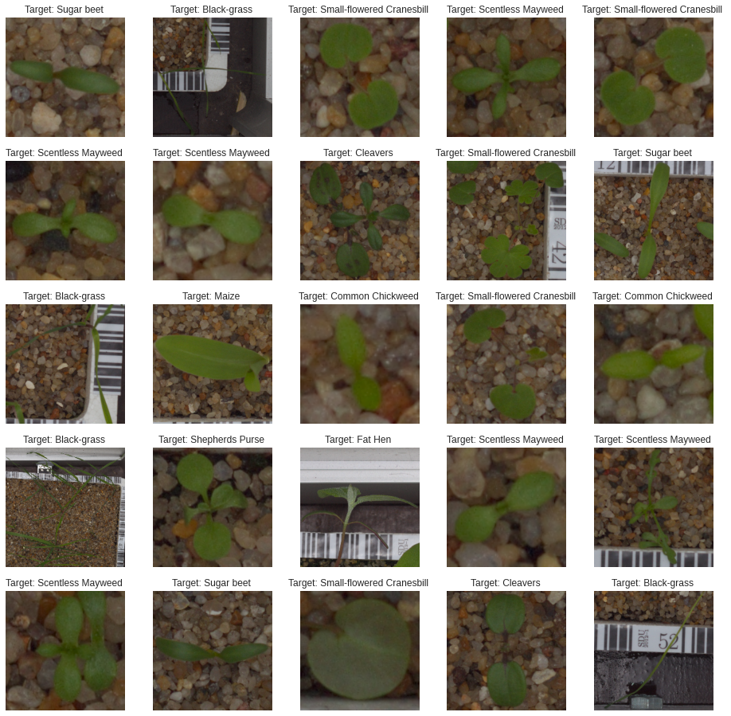

```python
plt.figure(figsize = (16,16))
image1, label1 = next(iter(train_data))
for i in range(0,25) :

    ax = plt.subplot(5,5,i+1)
    plt.imshow(image1[i]/255.)
    plt.title(f"Target: {class_names[tf.argmax(label1[i])]} ")
    ax.axis("off")
```

```python
def read_img(filepath, size):
    """
    Load images from files into array (using keras.image)
    """
    img = image.load_img(filepath, target_size=size)
    img = image.img_to_array(img)
    return img

# ## Display Representative thumbnails of each species
# fig = plt.figure(1, figsize=(12,12))
# grid = ImageGrid(fig, 111, nrows_ncols=(12,8), axes_pad=0.05)
# i = 0
# for category_id, category in enumerate(categories):
#     for filepath in df[df['label'] == category_id]['file'].values[:8]:
#         ax = grid[i]
#         #img = read_img('..\\input\\'+filepath, (47, 47))
#         img = read_img(filepath, (47, 47))
#         ax.imshow(img / 255.)
#         ax.axis('off')
#         if i % 8 == 2:
#             ax.text(300, 40 - i*0.3, filepath.split('\\')[3],fontsize=15)
#         i += 1
# plt.show();
```

```python
## Print number of images for each species
n=[]
for i in range(12):
    n.append(df[df.label==i].shape[0])
number = pd.DataFrame({'label': categories, 'n': n})

print('=========Number of images for each category==========')
number.sort_values('n',ascending=False)
```

```
=========Number of images for each category==========
```

|  | label | n |
| --- | --- | --- |
| 6 | Loose Silky-bent | 654 |
| 3 | Common Chickweed | 611 |
| 8 | Scentless Mayweed | 516 |
| 10 | Small-flowered Cranesbill | 496 |
| 5 | Fat Hen | 475 |
| 1 | Charlock | 390 |
| 11 | Sugar beet | 385 |
| 2 | Cleavers | 287 |
| 0 | Black-grass | 263 |
| 9 | Shepherds Purse | 231 |
| 4 | Common wheat | 221 |
| 7 | Maize | 221 |

As you can see above, the classes are slightly imbalanced. It might be helpful to downsample or upsample to have a more balanced dataset. For my first pass, I will use the full dataset.

```python
## Examine the distributions of image dimensions
s=[]
for i in df.file.values:
    m = image.img_to_array(image.load_img(i))
    s.append(m.shape)

dimension = pd.DataFrame({'label': data.target, 'file': data.filenames, 'dim':s})
```

```python
dimension.head()
```

|  | label | file | dim |
| --- | --- | --- | --- |
| 0 | 9 | ./plant-seedlings-classification/train/Shepher... | (98, 98, 3) |
| 1 | 5 | ./plant-seedlings-classification/train/Fat Hen... | (178, 178, 3) |
| 2 | 3 | ./plant-seedlings-classification/train/Common ... | (410, 410, 3) |
| 3 | 10 | ./plant-seedlings-classification/train/Small-f... | (209, 209, 3) |
| 4 | 2 | ./plant-seedlings-classification/train/Cleaver... | (190, 190, 3) |

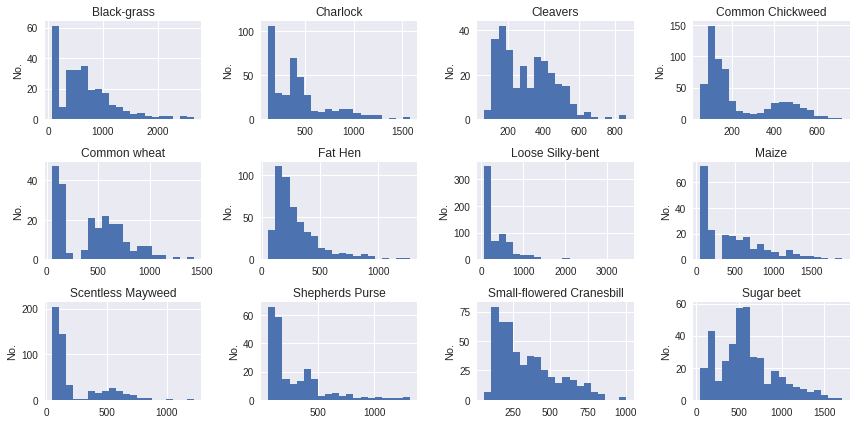

```python
def plot_hist_dim(dimension, title):
    """
    Make a histogram of image sizes
    """
    dimension.dim.apply(lambda x: x[0]).hist(bins=20)
    plt.title(title)
    plt.ylabel('No.')

plt.figure(1, figsize=(12,6))
for i in range(12):
    plt.subplot(3,4,i+1)
    plot_hist_dim(dimension[dimension['label']==i],categories[i])
plt.tight_layout()
plt.show()
```

There are pretty wide distributions of image sizes, spanning about 47 to more than 2000. Note that the images were taken at various stages of seedlings growth. Therefore, the earliest stages (when the seedlings were the smallest) would have smaller cropped images containing seedlings.

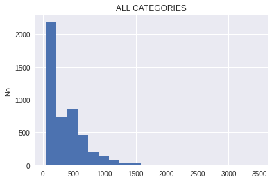

```python
plt.figure(1, figsize=(6,4))
plot_hist_dim(dimension,'ALL CATEGORIES')
```

## 3. Preprocessing & Sampling

To preprocess the input images, I resize them to a uniform scale. I also need to decide whether to use all three color chanels (RGB) in my model or whether to convert them all to grey scale. Furthermore, I need to decide whether to upsample some of the classes that are less numerous, to downsample some of the classes that are more numerous, or to leave the samples unchanged. Overall, I have the following pre-processing decisions:

(1) Image size (small, medium, large)  
(2) RGB vs Grey  
(3) All data, downsampling or upsampling

So, speaking of upsampling, Keras has ImageDataGenerator, which performs Image Augmentation to make a new set of representative images, based on slight modification to existing input images (i.e., by rotating, shifting, or flipping)

**Reading Images**

In this step, we simply store the path to our image dataset into a variable and then we create a function to load folders containing images into arrays so that computers can deal with it.

```python
from glob import glob
images = []
classes=[]
missing=0
for class_folder_name in os.listdir(TRAIN_FOLDER):
    class_folder_path = os.path.join(TRAIN_FOLDER, class_folder_name)
    class_label = class_folder_name

    for image_path in glob(os.path.join(class_folder_path, "*.png")):
        image_bgr = cv2.imread(image_path, cv2.IMREAD_COLOR)
        if image_bgr is None: # if the file contain any missing value ignore it
          missing += 1
          continue
        images.append(image_bgr)

        classes.append(class_label)
```

```python
len(images)
```

```
4750
```

**Resizing images** Some images captured by a camera and fed to our AI algorithm vary in size, therefore, we should establish a base size for all images fed into our AI algorithms by resizing them.

```python
# resize image

def resize_images(image1):

  image1 = np.array(image1).astype(np.uint8)
  #print(img.dtype)
  res = cv2.resize(image1,(256,256), interpolation = cv2.INTER_CUBIC)
  return res

#save resized images into images.
images = [resize_images(image1) for image1 in images]
```

```python
images[0].shape
```

```
(256, 256, 3)
```

```python
#see number of images in each label
images = np.array(images)
classes = np.array(classes)
print("images shape: ", images.shape)
print("classes shape: ", classes.shape)
```

```
images shape:  (4750, 256, 256, 3)
classes shape:  (4750,)
```

**Viewing the distribution of number of images in each class**

[figure not shown]

```python
import matplotlib as mp

values =[]
labels=[]
for label in set(classes):
  values.append(len(images[classes == label]))
  labels.append(label)

values.sort()

code=np.arange(0,13,1)
data_normalizer = mp.colors.Normalize()
color_map = mp.colors.LinearSegmentedColormap(
    "my_map",
    {
        "red": [(0, 1.0, 1.0),
                (1.0, .5, .5)],
        "green": [(0, 0.5, 0.5),
                  (1.0, 0, 0)],
        "blue": [(0, 0.50, 0.5),
                 (1.0, 0, 0)]
    }
)

fig, ax = plt.subplots(figsize=(22,7))
ax.bar(labels, values, color=color_map(data_normalizer(code)))
plt.xticks(fontsize = 8)
plt.yticks(fontsize = 10)
plt.xlabel("Species", fontsize = 14)
plt.ylabel("Number of images", fontsize = 14)
plt.title("Distribution of images in each class", fontsize=14)
plt.show()
```

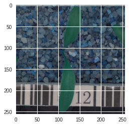

```python
plt.imshow(images[50])
```

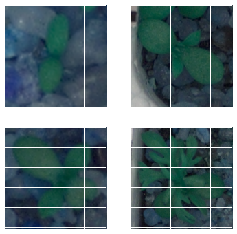

```python
def plot_for_class(label):
    nb_rows = 2
    nb_cols = 2
    fig, axs = plt.subplots(nb_rows, nb_cols, figsize=(6, 6))
    class_images =images[classes== label]
    n = 0
    for i in range(0, nb_rows):
        for j in range(0, nb_cols):
            axs[i, j].xaxis.set_ticklabels([])
            axs[i, j].yaxis.set_ticklabels([])
            axs[i, j].imshow(class_images[n])
            n += 1
plot_for_class("Scentless Mayweed")
```

```python
#!ls "train/Scentless Mayweed" 1300c3cd9.png

img = cv2.imread("./plant-seedlings-classification/train/Scentless Mayweed/1300c3cd9.png")
```

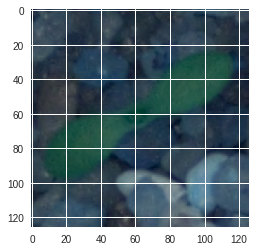

```python
plt.imshow(img)
```

# **Image Classification**

Structure of an Image Classification Task

1. Image Preprocessing - The aim of this process is to improve the image data (features) by suppressing unwanted distortions and enhancement of some important image features so that our Computer Vision models can benefit from this improved data to work on.
2. Detection of an object - Detection refers to the localization of an object which means the segmentation of the image and identifying the position of the object of interest.
3. Feature extraction and Training- This is a crucial step wherein statistical or deep learning methods are used to identify the most interesting patterns of the image, features that might be unique to a particular class and that will, later on, help the model to differentiate between different classes. This process where the model learns the features from the dataset is called model training.
4. Classification of the object - This step categorizes detected objects into predefined classes by using a suitable classification technique that compares the image patterns with the target patterns.

# *Image Preprocessing*

Pre-processing is a common name for operations with images at the lowest level of abstraction — both input and output are intensity images.

Need for Image-Preprocessing:

Computers are able to perform computations on numbers and is unable to interpret images in the way that we do. We have to somehow convert the images to numbers for the computer to understand. The aim of pre-processing is an improvement of the image data that suppresses unwilling distortions or enhances some image features important for further processing.

**Converting images from RGB to HSV and applying mophological transformations**

```python
def create_mask_for_plant(image):
    image_hsv = cv2.cvtColor(image, cv2.COLOR_BGR2HSV)

    sensitivity = 35
    lower_hsv = np.array([60 - sensitivity, 100, 50])
    upper_hsv = np.array([60 + sensitivity, 255, 255])

    mask = cv2.inRange(image_hsv, lower_hsv, upper_hsv)
    kernel = cv2.getStructuringElement(cv2.MORPH_ELLIPSE, (11,11))
    mask = cv2.morphologyEx(mask, cv2.MORPH_CLOSE, kernel)

    return mask
```

**Applying Segmentation**

```python
def segment_plant(image):
    mask = create_mask_for_plant(image)
    output = cv2.bitwise_and(image, image, mask = mask)
    return output
```

**Applying Sharpening**

```python
def sharpen_image(image):
    image_blurred = cv2.GaussianBlur(image, (0, 0), 3)
    image_sharp = cv2.addWeighted(image, 1.5, image_blurred, -0.5, 0)
    return image_sharp
```

```python
# Combining all functions

def preprocess(img):
  image_segmented = segment_plant(img)
  image_sharpen = sharpen_image(image_segmented)
  return image_sharpen

for indx, image in enumerate(images):
  try:
    images[indx] = preprocess(image)

  except:
    print(indx)
    continue
```

**Viewing the pre-processed images**

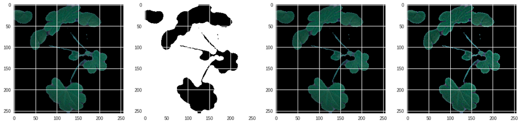

```python
images = np.array(images)
classes = np.array(classes)
image = images[classes == "Small-flowered Cranesbill"][40]

image_mask = create_mask_for_plant(image)
image_segmented = segment_plant(image)
image_sharpen = sharpen_image(image_segmented)

fig, axs = plt.subplots(1, 4, figsize=(20, 20))
axs[0].imshow(image)
axs[1].imshow(image_mask)
axs[2].imshow(image_segmented)
axs[3].imshow(image_sharpen)
```

```python
model_performance = pd.DataFrame(columns=['Model', 'Accuracy', 'Loss','Predicted Class'])
```

```python
number_of_columns = images[1].shape[0] * images[1].shape[1]
print(number_of_columns)
```

```
65536
```

**Reading the image to predict**

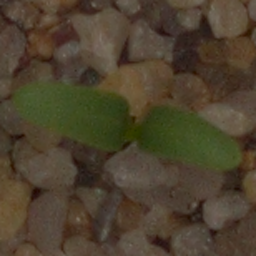

```
The shape of image to be predicted is:'(154, 154, 3)'
The shape of image to be predicted after expanding the dimensions is:'(1, 256, 256, 3)'
```

```python
from google.colab.patches import cv2_imshow

img_pred = cv2.imread('/content/drive/MyDrive/Dataset/Seedling/Predict.png')
img_pred_resize = cv2.resize(img_pred,(256,256), interpolation = cv2.INTER_CUBIC)
cv2_imshow(img_pred_resize)
img_predict = np.expand_dims(img_pred_resize, axis=0)
print(f"The shape of image to be predicted is:'{img_pred.shape}'")
print(f"The shape of image to be predicted after expanding the dimensions is:'{img_predict.shape}'")
```

**Encoding the Target Variable**

```python
from sklearn.preprocessing import LabelEncoder

enc = LabelEncoder()
y = enc.fit_transform(classes)

num_classes = len(np.unique(y))
num_classes
```

```
12
```

**Splitting data into training and testing set**

training set : 70%

testing set: 30%

```python
X_train, X_test, y_train, y_test = train_test_split(images, y, test_size=0.3, random_state=50)
```

**Creating validation set**

splitting test and validation sets each with 50% of data

```python
random_seed = 2
X_test, X_val, y_test, y_val = train_test_split(X_test,y_test, test_size = 0.5, random_state=random_seed)
```

```python
print(f"#### Shapes of Train, Test and Validation sets are: {X_train.shape},{X_test.shape},{X_val.shape}")
```

```
#### Shapes of Train, Test and Validation sets are: (3325, 256, 256, 3),(712, 256, 256, 3),(713, 256, 256, 3)
```

```python
print(f"#### Shapes of Train, Test and Validation sets of Target are: {y_train.shape},{y_test.shape},{y_val.shape}")
```

```
#### Shapes of Train, Test and Validation sets of Target are: (3325,),(712,),(713,)
```

# *Classification using Convolution Neural Network (CNN)*

```python
from tensorflow.python.keras.layers import GlobalAveragePooling2D, Conv2D, MaxPool2D, GlobalMaxPool2D
from keras.layers import Dense, Dropout, Flatten, Conv2D, MaxPool2D, GlobalMaxPooling2D
from tensorflow.keras.optimizers import RMSprop

def cnn_model(height, width, num_channels, num_classes, loss='categorical_crossentropy', metrics=['accuracy']):
  batch_size = None

  model = Sequential()

  model.add(Conv2D(filters = 32, kernel_size = (5,5),padding = 'Same',
                  activation ='relu', batch_input_shape = (batch_size,height, width, num_channels)))


  model.add(Conv2D(filters = 32, kernel_size = (5,5),padding = 'Same',
                  activation ='relu'))
  model.add(MaxPool2D(pool_size=(2,2)))
  model.add(Dropout(0.2))


  model.add(Conv2D(filters = 64, kernel_size = (3,3),padding = 'Same',
                  activation ='relu'))
  model.add(Conv2D(filters = 64, kernel_size = (3,3),padding = 'same',
                  activation ='relu'))
  model.add(MaxPool2D(pool_size=(2,2), strides=(2,2)))
  model.add(Dropout(0.3))

  model.add(Conv2D(filters = 128, kernel_size = (3,3),padding = 'Same',
                  activation ='relu'))
  model.add(Conv2D(filters = 128, kernel_size = (3,3),padding = 'Same',
                  activation ='relu'))
  model.add(MaxPool2D(pool_size=(2,2), strides=(2,2)))
  model.add(Dropout(0.4))



  model.add(GlobalMaxPooling2D())
  model.add(Dense(256, activation = "relu"))
  model.add(Dropout(0.5))
  model.add(Dense(num_classes, activation = "softmax"))

  optimizer = RMSprop(lr=0.001, rho=0.9, epsilon=1e-08, decay=0.0)
  model.compile(optimizer = optimizer, loss = loss, metrics = metrics)
  model.summary()
  return model
```

```python
cnn = cnn_model(256,256,3,12)
```

```
Model: "sequential"
_________________________________________________________________
 Layer (type)                Output Shape              Param #
=================================================================
 conv2d (Conv2D)             (None, 256, 256, 32)      2432

 conv2d_1 (Conv2D)           (None, 256, 256, 32)      25632

 max_pooling2d (MaxPooling2D  (None, 128, 128, 32)     0
 )

 dropout (Dropout)           (None, 128, 128, 32)      0

 conv2d_2 (Conv2D)           (None, 128, 128, 64)      18496

 conv2d_3 (Conv2D)           (None, 128, 128, 64)      36928

 max_pooling2d_1 (MaxPooling  (None, 64, 64, 64)       0
 2D)

 dropout_1 (Dropout)         (None, 64, 64, 64)        0

 conv2d_4 (Conv2D)           (None, 64, 64, 128)       73856

 conv2d_5 (Conv2D)           (None, 64, 64, 128)       147584

 max_pooling2d_2 (MaxPooling  (None, 32, 32, 128)      0
 2D)

 dropout_2 (Dropout)         (None, 32, 32, 128)       0

 global_max_pooling2d (Globa  (None, 128)              0
 lMaxPooling2D)

 dense (Dense)               (None, 256)               33024

 dropout_3 (Dropout)         (None, 256)               0

 dense_1 (Dense)             (None, 12)                3084

=================================================================
Total params: 341,036
Trainable params: 341,036
Non-trainable params: 0
_________________________________________________________________
```

```python
history = cnn.fit(X_train, y_train, epochs = 50, validation_data = (X_val,y_val), batch_size = None)
```

[output not shown]

```python
cnn_loss, cnn_accuracy = cnn.evaluate(X_test, y_test, verbose=1)
print('Test loss:', cnn_loss)
print('Test accuracy:', cnn_accuracy)
```

[output not shown]

```python
cnn_predict = np.argmax(cnn.predict(img_predict))
```

```python
model_performance = model_performance.append({'Model':'CNN',
                                              'Accuracy': cnn_accuracy,
                                              'Loss': cnn_loss,
                                              'Predicted Class': cnn_predict
                                              }, ignore_index=True)

model_performance
```

[output not shown]

**Data Augmentation**

```python
from keras.callbacks import ReduceLROnPlateau

learning_rate_reduction = ReduceLROnPlateau(monitor='val_acc',
                                            patience=3,
                                            verbose=1,
                                            factor=0.5,
                                            min_lr=0.00001)
epochs = 30
batch_size = 38
```

```python
# With data augmentation to prevent overfitting

datagen = ImageDataGenerator(
        featurewise_center=False,  # set input mean to 0 over the dataset
        samplewise_center=False,  # set each sample mean to 0
        featurewise_std_normalization=False,  # divide inputs by std of the dataset
        samplewise_std_normalization=False,  # divide each input by its std
        zca_whitening=False,  # apply ZCA whitening
        rotation_range=10,  # randomly rotate images in the range (degrees, 0 to 180)
        zoom_range = 0.1, # Randomly zoom image
        width_shift_range=0.1,  # randomly shift images horizontally (fraction of total width)
        height_shift_range=0.1,  # randomly shift images vertically (fraction of total height)
        horizontal_flip=False,  # randomly flip images
        vertical_flip=False)  # randomly flip images


datagen.fit(X_train)
```

```python
# X_train, X_test, y_train, y_test
history = cnn.fit(datagen.flow(X_train,y_train, batch_size=batch_size),
                              epochs = epochs, validation_data = (X_val,Y_val),
                              verbose = 2, steps_per_epoch=X_train.shape[0] // batch_size
                              , callbacks=[learning_rate_reduction])
```

[output not shown]

```python
cnn_loss_aug, cnn_accuracy_aug = cnn.evaluate(X_test, y_test, verbose=1)
print('Test loss:', cnn_loss_aug)
print('Test accuracy:', cnn_accuracy_aug)
```

[output not shown]

**Model Evaluation**

[output not shown]

[figure not shown]

```python
fig, ax = plt.subplots(2,1 , figsize=(22,7))
ax[0].plot(history.history['loss'], color='b', label="Training loss")
ax[0].plot(history.history['val_loss'], color='r', label="validation loss",axes =ax[0])
legend = ax[0].legend(loc='best', shadow=True)

ax[1].plot(history.history['accuracy'], color='b', label="Training accuracy")
ax[1].plot(history.history['val_accuracy'], color='r',label="Validation accuracy")
legend = ax[1].legend(loc='best', shadow=True)
```

```python
from sklearn.metrics import confusion_matrix
import itertools
plt.subplots(figsize=(22,7)) #set the size of the plot

def plot_confusion_matrix(cm, classes,
                          normalize=False,
                          title='Confusion matrix',
                          cmap=plt.cm.Blues):
    """
    This function prints and plots the confusion matrix.
    Normalization can be applied by setting `normalize=True`.
    """
    plt.imshow(cm, interpolation='nearest', cmap=cmap)
    plt.title(title)
    plt.colorbar()
    tick_marks = np.arange(len(classes))
    plt.xticks(tick_marks, classes, rotation=45)
    plt.yticks(tick_marks, classes)

    if normalize:
        cm = cm.astype('float') / cm.sum(axis=1)[:, np.newaxis]

    thresh = cm.max() / 2.
    for i, j in itertools.product(range(cm.shape[0]), range(cm.shape[1])):
        plt.text(j, i, cm[i, j],
                 horizontalalignment="center",
                 color="white" if cm[i, j] > thresh else "black")

    plt.tight_layout()
    plt.ylabel('True label')
    plt.xlabel('Predicted label')

# Predict the values from the validation dataset
Y_pred = model.predict(X_val)
# Convert predictions classes to one hot vectors
Y_pred_classes = np.argmax(Y_pred,axis = 1)
# Convert validation observations to one hot vectors
Y_true = np.argmax(Y_val,axis = 1)
# compute the confusion matrix
confusion_mtx = confusion_matrix(Y_true, Y_pred_classes)
# plot the confusion matrix
plot_confusion_matrix(confusion_mtx, classes = range(10))
```

[output not shown]

```python
cnn_predict_aug = np.argmax(cnn.predict(img_predict))
```

```python
print('The predicted flower is with label:', cnn_predict)
```

[output not shown]

```python
model_performance = model_performance.append({'Model':'CNN with Data Augmentaion',
                                              'Accuracy': cnn_accuracy_aug,
                                              'Loss': cnn_loss_aug,
                                              'Predicted Class': cnn_predict_aug
                                              }, ignore_index=True)

model_performance
```

[output not shown]

**Saving the best model**

```python
model.save("CNN_PlantSeedling_ImageClassification.h5")
```

# **Conclusion**

The best part of CNNs is high accuracy of image prediction and less loss. Also, we do not have to do feature extraction. The system learns to do feature extraction and the core concept of CNN is, it uses convolution of image and filters to generate invariant features which are passed on to the next layer. The features in the next layer are convoluted with different filters to generate more invariant and abstract features and the process continues till one gets final feature / output which is invariant to occlusions. ANNs are better than Supervised Learning models because we don't have to perform feature extraction in ANNS whereas in Supervised Learning, we must perform the Principal component analysis (PCA) to compute the principal components in images.